# Risk Factor Analysis

## Outcome Variable

**Outcome Variable:** ever_sstunted

## Predictor Variables

**Intervention Variable:** meducyrs

**Adjustment Set:**

- arm
- W_mage
- feducyrs
- hhwealth_quart
- W_mhtcm
- W_mwtkg
- W_mbmi
- W_gagebrth
- W_birthwt
- W_birthlen
- single
- W_nrooms
- impsan
- delta_W_mage
- delta_feducyrs
- delta_hhwealth_quart
- delta_W_mhtcm
- delta_W_mwtkg
- delta_W_mbmi
- delta_W_gagebrth
- delta_W_birthwt
- delta_W_birthlen
- delta_single
- delta_W_nrooms
- delta_impsan

## Stratifying Variables

The analysis was stratified on these variable(s):

- agecat
- studyid
- country

## Data Summary

| agecat | studyid | country | meducyrs | ever_sstunted | n_cell | n |
| --- | --- | --- | --- | --- | --- | --- |
| 0-24 months | CMC-V-BCS-2002 | INDIA | High | 0 | 65 | 373 |
| 0-24 months | CMC-V-BCS-2002 | INDIA | High | 1 | 93 | 373 |
| 0-24 months | CMC-V-BCS-2002 | INDIA | Low | 0 | 37 | 373 |
| 0-24 months | CMC-V-BCS-2002 | INDIA | Low | 1 | 69 | 373 |
| 0-24 months | CMC-V-BCS-2002 | INDIA | Medium | 0 | 34 | 373 |
| 0-24 months | CMC-V-BCS-2002 | INDIA | Medium | 1 | 75 | 373 |
| 0-24 months | COHORTS | GUATEMALA | High | 0 | 161 | 1341 |
| 0-24 months | COHORTS | GUATEMALA | High | 1 | 124 | 1341 |
| 0-24 months | COHORTS | GUATEMALA | Low | 0 | 326 | 1341 |
| 0-24 months | COHORTS | GUATEMALA | Low | 1 | 310 | 1341 |
| 0-24 months | COHORTS | GUATEMALA | Medium | 0 | 232 | 1341 |
| 0-24 months | COHORTS | GUATEMALA | Medium | 1 | 188 | 1341 |
| 0-24 months | COHORTS | INDIA | High | 0 | 761 | 5852 |
| 0-24 months | COHORTS | INDIA | High | 1 | 32 | 5852 |
| 0-24 months | COHORTS | INDIA | Low | 0 | 1530 | 5852 |
| 0-24 months | COHORTS | INDIA | Low | 1 | 426 | 5852 |
| 0-24 months | COHORTS | INDIA | Medium | 0 | 2788 | 5852 |
| 0-24 months | COHORTS | INDIA | Medium | 1 | 315 | 5852 |
| 0-24 months | COHORTS | PHILIPPINES | High | 0 | 885 | 3058 |
| 0-24 months | COHORTS | PHILIPPINES | High | 1 | 288 | 3058 |
| 0-24 months | COHORTS | PHILIPPINES | Low | 0 | 481 | 3058 |
| 0-24 months | COHORTS | PHILIPPINES | Low | 1 | 422 | 3058 |
| 0-24 months | COHORTS | PHILIPPINES | Medium | 0 | 603 | 3058 |
| 0-24 months | COHORTS | PHILIPPINES | Medium | 1 | 379 | 3058 |
| 0-24 months | EE | PAKISTAN | High | 0 | 8 | 376 |
| 0-24 months | EE | PAKISTAN | High | 1 | 7 | 376 |
| 0-24 months | EE | PAKISTAN | Low | 0 | 122 | 376 |
| 0-24 months | EE | PAKISTAN | Low | 1 | 206 | 376 |
| 0-24 months | EE | PAKISTAN | Medium | 0 | 20 | 376 |
| 0-24 months | EE | PAKISTAN | Medium | 1 | 13 | 376 |

[output cut: 282 more lines]

The following strata were considered:

- agecat: 0-24 months, studyid: CMC-V-BCS-2002, country: INDIA
- agecat: 0-24 months, studyid: COHORTS, country: GUATEMALA
- agecat: 0-24 months, studyid: COHORTS, country: INDIA
- agecat: 0-24 months, studyid: COHORTS, country: PHILIPPINES
- agecat: 0-24 months, studyid: EE, country: PAKISTAN
- agecat: 0-24 months, studyid: GMS-Nepal, country: NEPAL
- agecat: 0-24 months, studyid: Guatemala BSC, country: GUATEMALA
- agecat: 0-24 months, studyid: IRC, country: INDIA
- agecat: 0-24 months, studyid: JiVitA-3, country: BANGLADESH
- agecat: 0-24 months, studyid: JiVitA-4, country: BANGLADESH
- agecat: 0-24 months, studyid: LCNI-5, country: MALAWI
- agecat: 0-24 months, studyid: MAL-ED, country: BANGLADESH
- agecat: 0-24 months, studyid: MAL-ED, country: BRAZIL
- agecat: 0-24 months, studyid: MAL-ED, country: INDIA
- agecat: 0-24 months, studyid: MAL-ED, country: NEPAL
- agecat: 0-24 months, studyid: MAL-ED, country: PERU
- agecat: 0-24 months, studyid: MAL-ED, country: SOUTH AFRICA
- agecat: 0-24 months, studyid: MAL-ED, country: TANZANIA, UNITED REPUBLIC OF
- agecat: 0-24 months, studyid: NIH-Birth, country: BANGLADESH
- agecat: 0-24 months, studyid: NIH-Crypto, country: BANGLADESH
- agecat: 0-24 months, studyid: PROBIT, country: BELARUS
- agecat: 0-24 months, studyid: PROVIDE, country: BANGLADESH
- agecat: 0-24 months, studyid: SAS-CompFeed, country: INDIA
- agecat: 0-24 months, studyid: SAS-FoodSuppl, country: INDIA
- agecat: 0-24 months, studyid: TanzaniaChild2, country: TANZANIA, UNITED REPUBLIC OF
- agecat: 0-24 months, studyid: ZVITAMBO, country: ZIMBABWE
- agecat: 0-6 months, studyid: CMC-V-BCS-2002, country: INDIA
- agecat: 0-6 months, studyid: COHORTS, country: GUATEMALA
- agecat: 0-6 months, studyid: COHORTS, country: INDIA
- agecat: 0-6 months, studyid: COHORTS, country: PHILIPPINES
- agecat: 0-6 months, studyid: EE, country: PAKISTAN
- agecat: 0-6 months, studyid: GMS-Nepal, country: NEPAL
- agecat: 0-6 months, studyid: Guatemala BSC, country: GUATEMALA
- agecat: 0-6 months, studyid: IRC, country: INDIA
- agecat: 0-6 months, studyid: JiVitA-3, country: BANGLADESH
- agecat: 0-6 months, studyid: JiVitA-4, country: BANGLADESH
- agecat: 0-6 months, studyid: LCNI-5, country: MALAWI
- agecat: 0-6 months, studyid: MAL-ED, country: BANGLADESH
- agecat: 0-6 months, studyid: MAL-ED, country: BRAZIL
- agecat: 0-6 months, studyid: MAL-ED, country: INDIA
- agecat: 0-6 months, studyid: MAL-ED, country: NEPAL
- agecat: 0-6 months, studyid: MAL-ED, country: PERU
- agecat: 0-6 months, studyid: MAL-ED, country: SOUTH AFRICA
- agecat: 0-6 months, studyid: MAL-ED, country: TANZANIA, UNITED REPUBLIC OF
- agecat: 0-6 months, studyid: NIH-Birth, country: BANGLADESH
- agecat: 0-6 months, studyid: NIH-Crypto, country: BANGLADESH
- agecat: 0-6 months, studyid: PROBIT, country: BELARUS
- agecat: 0-6 months, studyid: PROVIDE, country: BANGLADESH
- agecat: 0-6 months, studyid: SAS-CompFeed, country: INDIA
- agecat: 0-6 months, studyid: SAS-FoodSuppl, country: INDIA
- agecat: 0-6 months, studyid: TanzaniaChild2, country: TANZANIA, UNITED REPUBLIC OF
- agecat: 0-6 months, studyid: ZVITAMBO, country: ZIMBABWE

### Dropped Strata

Some strata were dropped due to rare outcomes:

- agecat: 0-24 months, studyid: MAL-ED, country: BRAZIL
- agecat: 0-6 months, studyid: Guatemala BSC, country: GUATEMALA
- agecat: 0-6 months, studyid: LCNI-5, country: MALAWI
- agecat: 0-6 months, studyid: MAL-ED, country: BANGLADESH
- agecat: 0-6 months, studyid: MAL-ED, country: BRAZIL
- agecat: 0-6 months, studyid: MAL-ED, country: INDIA
- agecat: 0-6 months, studyid: MAL-ED, country: NEPAL
- agecat: 0-6 months, studyid: MAL-ED, country: TANZANIA, UNITED REPUBLIC OF
- agecat: 0-6 months, studyid: PROVIDE, country: BANGLADESH
- agecat: 0-6 months, studyid: SAS-FoodSuppl, country: INDIA
- agecat: 0-6 months, studyid: TanzaniaChild2, country: TANZANIA, UNITED REPUBLIC OF

## Methods Detail

We’re interested in the causal parameters $E[Y_a]$ for all values of $a \in \mathcal{A}$. These parameters represent the mean outcome if, possibly contrary to fact, we intervened to set all units to have $A=a$. Under the randomization and positivity assumptions, these are identified by the statistical parameters $\psi_a=E_W[E_{Y|A,W}(Y|A=a,W)]$. In addition, we’re interested in the mean of $Y$, $E[Y]$ under no intervention (the observed mean). We will estimate these parameters by using SuperLearner to fit the relevant likelihood factors – $E_{Y|A,W}(Y|A=a,W)$ and $p(A=a|W)$, and then updating our likelihood fit using a joint TMLE.

For unadjusted analyses ($W=\{\}$), initial likelihoods were estimated using Lrnr_glm to estimate the simple $E(Y|A)$ and Lrnr_mean to estimate $p(A)$. For adjusted analyses, a small library containing Lrnr_glmnet, Lrnr_xgboost, and Lrnr_mean was used.

Having estimated these parameters, we will then use the delta method to estimate relative risks and attributable risks relative to a prespecified baseline level of $A$.

# Results Detail

## Results Plots

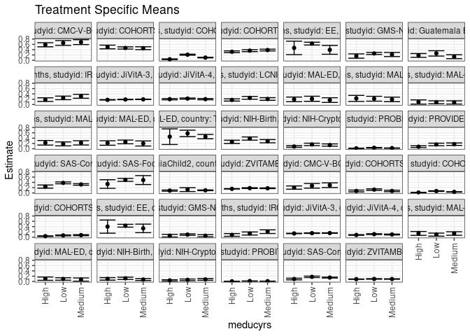

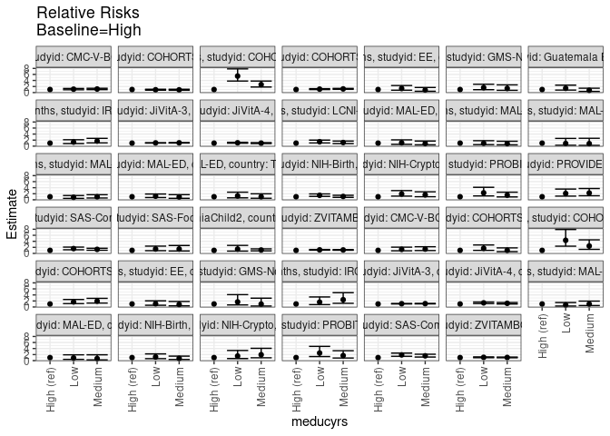

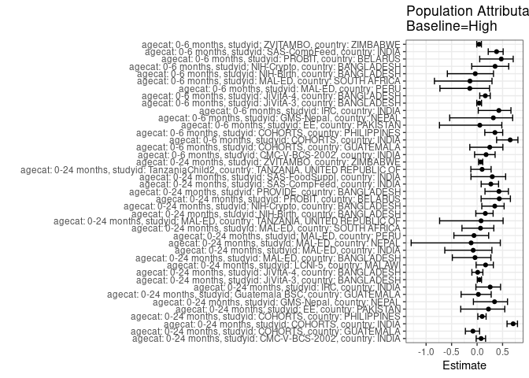

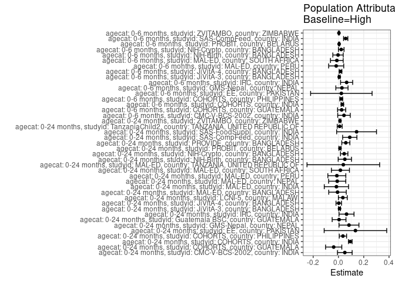

## Results Table

### Parameter: TSM

| agecat | studyid | country | intervention_level | baseline_level | estimate | ci_lower | ci_upper |
| --- | --- | --- | --- | --- | --- | --- | --- |
| 0-24 months | CMC-V-BCS-2002 | INDIA | High | NA | 0.5852110 | 0.5078588 | 0.6625633 |
| 0-24 months | CMC-V-BCS-2002 | INDIA | Low | NA | 0.6532860 | 0.5615631 | 0.7450089 |
| 0-24 months | CMC-V-BCS-2002 | INDIA | Medium | NA | 0.6835280 | 0.5924468 | 0.7746093 |
| 0-24 months | COHORTS | GUATEMALA | High | NA | 0.5015929 | 0.4321500 | 0.5710358 |
| 0-24 months | COHORTS | GUATEMALA | Low | NA | 0.4642378 | 0.4224883 | 0.5059873 |
| 0-24 months | COHORTS | GUATEMALA | Medium | NA | 0.4555420 | 0.4011820 | 0.5099020 |
| 0-24 months | COHORTS | INDIA | High | NA | 0.0386240 | 0.0250878 | 0.0521601 |
| 0-24 months | COHORTS | INDIA | Low | NA | 0.2107815 | 0.1915127 | 0.2300503 |
| 0-24 months | COHORTS | INDIA | Medium | NA | 0.1019924 | 0.0909790 | 0.1130058 |
| 0-24 months | COHORTS | PHILIPPINES | High | NA | 0.3207100 | 0.2878979 | 0.3535222 |
| 0-24 months | COHORTS | PHILIPPINES | Low | NA | 0.3634354 | 0.3269077 | 0.3999630 |
| 0-24 months | COHORTS | PHILIPPINES | Medium | NA | 0.3856719 | 0.3518143 | 0.4195295 |
| 0-24 months | EE | PAKISTAN | High | NA | 0.4666667 | 0.2138629 | 0.7194704 |
| 0-24 months | EE | PAKISTAN | Low | NA | 0.6280488 | 0.5756732 | 0.6804244 |
| 0-24 months | EE | PAKISTAN | Medium | NA | 0.3939394 | 0.2270064 | 0.5608724 |
| 0-24 months | GMS-Nepal | NEPAL | High | NA | 0.1598864 | 0.0786673 | 0.2411055 |
| 0-24 months | GMS-Nepal | NEPAL | Low | NA | 0.2581159 | 0.2187047 | 0.2975271 |
| 0-24 months | GMS-Nepal | NEPAL | Medium | NA | 0.2186253 | 0.1411021 | 0.2961486 |
| 0-24 months | Guatemala BSC | GUATEMALA | High | NA | 0.1831761 | 0.1118191 | 0.2545330 |
| 0-24 months | Guatemala BSC | GUATEMALA | Low | NA | 0.2592726 | 0.1590273 | 0.3595179 |
| 0-24 months | Guatemala BSC | GUATEMALA | Medium | NA | 0.1355926 | 0.0624670 | 0.2087183 |
| 0-24 months | IRC | INDIA | High | NA | 0.1849132 | 0.1159576 | 0.2538688 |
| 0-24 months | IRC | INDIA | Low | NA | 0.2494474 | 0.1819439 | 0.3169510 |
| 0-24 months | IRC | INDIA | Medium | NA | 0.3102203 | 0.2371522 | 0.3832884 |
| 0-24 months | JiVitA-3 | BANGLADESH | High | NA | 0.1760180 | 0.1670192 | 0.1850168 |
| 0-24 months | JiVitA-3 | BANGLADESH | Low | NA | 0.1898548 | 0.1797851 | 0.1999245 |
| 0-24 months | JiVitA-3 | BANGLADESH | Medium | NA | 0.1945705 | 0.1846020 | 0.2045390 |
| 0-24 months | JiVitA-4 | BANGLADESH | High | NA | 0.2011436 | 0.1766341 | 0.2256531 |
| 0-24 months | JiVitA-4 | BANGLADESH | Low | NA | 0.2237528 | 0.2020423 | 0.2454633 |
| 0-24 months | JiVitA-4 | BANGLADESH | Medium | NA | 0.2025004 | 0.1786499 | 0.2263508 |

[output cut: 93 more lines]

### Parameter: E(Y)

| agecat | studyid | country | intervention_level | baseline_level | estimate | ci_lower | ci_upper |
| --- | --- | --- | --- | --- | --- | --- | --- |
| 0-24 months | CMC-V-BCS-2002 | INDIA | NA | NA | 0.6353887 | 0.5864772 | 0.6843003 |
| 0-24 months | COHORTS | GUATEMALA | NA | NA | 0.4638330 | 0.4371320 | 0.4905339 |
| 0-24 months | COHORTS | INDIA | NA | NA | 0.1320916 | 0.1234158 | 0.1407674 |
| 0-24 months | COHORTS | PHILIPPINES | NA | NA | 0.3561151 | 0.3391405 | 0.3730897 |
| 0-24 months | EE | PAKISTAN | NA | NA | 0.6010638 | 0.5515023 | 0.6506253 |
| 0-24 months | GMS-Nepal | NEPAL | NA | NA | 0.2431655 | 0.2112486 | 0.2750823 |
| 0-24 months | Guatemala BSC | GUATEMALA | NA | NA | 0.1879433 | 0.1422659 | 0.2336207 |
| 0-24 months | IRC | INDIA | NA | NA | 0.2487805 | 0.2068840 | 0.2906770 |
| 0-24 months | JiVitA-3 | BANGLADESH | NA | NA | 0.1846063 | 0.1789984 | 0.1902143 |
| 0-24 months | JiVitA-4 | BANGLADESH | NA | NA | 0.2035431 | 0.1916695 | 0.2154167 |
| 0-24 months | LCNI-5 | MALAWI | NA | NA | 0.2076167 | 0.1797361 | 0.2354973 |
| 0-24 months | MAL-ED | BANGLADESH | NA | NA | 0.1869159 | 0.1345620 | 0.2392698 |
| 0-24 months | MAL-ED | INDIA | NA | NA | 0.2136364 | 0.1593519 | 0.2679208 |
| 0-24 months | MAL-ED | NEPAL | NA | NA | 0.0844444 | 0.0480318 | 0.1208571 |
| 0-24 months | MAL-ED | PERU | NA | NA | 0.2119205 | 0.1657530 | 0.2580880 |
| 0-24 months | MAL-ED | SOUTH AFRICA | NA | NA | 0.2324841 | 0.1856873 | 0.2792809 |
| 0-24 months | MAL-ED | TANZANIA, UNITED REPUBLIC OF | NA | NA | 0.4930876 | 0.4264146 | 0.5597605 |
| 0-24 months | NIH-Birth | BANGLADESH | NA | NA | 0.3116057 | 0.2753823 | 0.3478292 |
| 0-24 months | NIH-Crypto | BANGLADESH | NA | NA | 0.1306069 | 0.1066024 | 0.1546113 |
| 0-24 months | PROBIT | BELARUS | NA | NA | 0.0276380 | 0.0201988 | 0.0350773 |
| 0-24 months | PROVIDE | BANGLADESH | NA | NA | 0.1357143 | 0.1103250 | 0.1611036 |
| 0-24 months | SAS-CompFeed | INDIA | NA | NA | 0.3307241 | 0.3024794 | 0.3589688 |
| 0-24 months | SAS-FoodSuppl | INDIA | NA | NA | 0.4808612 | 0.4329065 | 0.5288160 |
| 0-24 months | TanzaniaChild2 | TANZANIA, UNITED REPUBLIC OF | NA | NA | 0.0993294 | 0.0873254 | 0.1113334 |
| 0-24 months | ZVITAMBO | ZIMBABWE | NA | NA | 0.1682795 | 0.1620941 | 0.1744649 |
| 0-6 months | CMC-V-BCS-2002 | INDIA | NA | NA | 0.2472826 | 0.2031431 | 0.2914222 |
| 0-6 months | COHORTS | GUATEMALA | NA | NA | 0.1011132 | 0.0831080 | 0.1191183 |
| 0-6 months | COHORTS | INDIA | NA | NA | 0.0473331 | 0.0418015 | 0.0528647 |
| 0-6 months | COHORTS | PHILIPPINES | NA | NA | 0.0624591 | 0.0538810 | 0.0710373 |
| 0-6 months | EE | PAKISTAN | NA | NA | 0.4228723 | 0.3728720 | 0.4728727 |
| 0-6 months | GMS-Nepal | NEPAL | NA | NA | 0.0863309 | 0.0654358 | 0.1072261 |
| 0-6 months | IRC | INDIA | NA | NA | 0.1512195 | 0.1164988 | 0.1859402 |
| 0-6 months | JiVitA-3 | BANGLADESH | NA | NA | 0.1475283 | 0.1424745 | 0.1525821 |
| 0-6 months | JiVitA-4 | BANGLADESH | NA | NA | 0.1013500 | 0.0923758 | 0.1103243 |
| 0-6 months | MAL-ED | PERU | NA | NA | 0.1258278 | 0.0883606 | 0.1632951 |
| 0-6 months | MAL-ED | SOUTH AFRICA | NA | NA | 0.0923567 | 0.0602816 | 0.1244318 |
| 0-6 months | NIH-Birth | BANGLADESH | NA | NA | 0.0937997 | 0.0709973 | 0.1166021 |
| 0-6 months | NIH-Crypto | BANGLADESH | NA | NA | 0.0620053 | 0.0448256 | 0.0791849 |
| 0-6 months | PROBIT | BELARUS | NA | NA | 0.0109519 | 0.0074064 | 0.0144975 |
| 0-6 months | SAS-CompFeed | INDIA | NA | NA | 0.1496732 | 0.1307571 | 0.1685893 |
| 0-6 months | ZVITAMBO | ZIMBABWE | NA | NA | 0.0913301 | 0.0865643 | 0.0960959 |

### Parameter: RR

| agecat | studyid | country | intervention_level | baseline_level | estimate | ci_lower | ci_upper |
| --- | --- | --- | --- | --- | --- | --- | --- |
| 0-24 months | CMC-V-BCS-2002 | INDIA | High | High | 1.0000000 | 1.0000000 | 1.000000 |
| 0-24 months | CMC-V-BCS-2002 | INDIA | Low | High | 1.1163255 | 0.9207945 | 1.353377 |
| 0-24 months | CMC-V-BCS-2002 | INDIA | Medium | High | 1.1680027 | 0.9679381 | 1.409419 |
| 0-24 months | COHORTS | GUATEMALA | High | High | 1.0000000 | 1.0000000 | 1.000000 |
| 0-24 months | COHORTS | GUATEMALA | Low | High | 0.9255270 | 0.7871191 | 1.088273 |
| 0-24 months | COHORTS | GUATEMALA | Medium | High | 0.9081906 | 0.7588798 | 1.086879 |
| 0-24 months | COHORTS | INDIA | High | High | 1.0000000 | 1.0000000 | 1.000000 |
| 0-24 months | COHORTS | INDIA | Low | High | 5.4572726 | 3.7995869 | 7.838175 |
| 0-24 months | COHORTS | INDIA | Medium | High | 2.6406515 | 1.8302944 | 3.809792 |
| 0-24 months | COHORTS | PHILIPPINES | High | High | 1.0000000 | 1.0000000 | 1.000000 |
| 0-24 months | COHORTS | PHILIPPINES | Low | High | 1.1332211 | 0.9842744 | 1.304707 |
| 0-24 months | COHORTS | PHILIPPINES | Medium | High | 1.2025564 | 1.0537469 | 1.372381 |
| 0-24 months | EE | PAKISTAN | High | High | 1.0000000 | 1.0000000 | 1.000000 |
| 0-24 months | EE | PAKISTAN | Low | High | 1.3458188 | 0.7779437 | 2.328225 |
| 0-24 months | EE | PAKISTAN | Medium | High | 0.8441558 | 0.4243530 | 1.679260 |
| 0-24 months | GMS-Nepal | NEPAL | High | High | 1.0000000 | 1.0000000 | 1.000000 |
| 0-24 months | GMS-Nepal | NEPAL | Low | High | 1.6143708 | 0.9494976 | 2.744813 |
| 0-24 months | GMS-Nepal | NEPAL | Medium | High | 1.3673793 | 0.7361598 | 2.539837 |
| 0-24 months | Guatemala BSC | GUATEMALA | High | High | 1.0000000 | 1.0000000 | 1.000000 |
| 0-24 months | Guatemala BSC | GUATEMALA | Low | High | 1.4154286 | 0.8177502 | 2.449939 |
| 0-24 months | Guatemala BSC | GUATEMALA | Medium | High | 0.7402312 | 0.3805144 | 1.440004 |
| 0-24 months | IRC | INDIA | High | High | 1.0000000 | 1.0000000 | 1.000000 |
| 0-24 months | IRC | INDIA | Low | High | 1.3489974 | 0.8554508 | 2.127293 |
| 0-24 months | IRC | INDIA | Medium | High | 1.6776537 | 1.0851717 | 2.593619 |
| 0-24 months | JiVitA-3 | BANGLADESH | High | High | 1.0000000 | 1.0000000 | 1.000000 |
| 0-24 months | JiVitA-3 | BANGLADESH | Low | High | 1.0786102 | 1.0113410 | 1.150354 |
| 0-24 months | JiVitA-3 | BANGLADESH | Medium | High | 1.1054011 | 1.0354588 | 1.180068 |
| 0-24 months | JiVitA-4 | BANGLADESH | High | High | 1.0000000 | 1.0000000 | 1.000000 |
| 0-24 months | JiVitA-4 | BANGLADESH | Low | High | 1.1124032 | 0.9594462 | 1.289745 |
| 0-24 months | JiVitA-4 | BANGLADESH | Medium | High | 1.0067454 | 0.8541686 | 1.186576 |

[output cut: 93 more lines]

### Parameter: PAR

| agecat | studyid | country | intervention_level | baseline_level | estimate | ci_lower | ci_upper |
| --- | --- | --- | --- | --- | --- | --- | --- |
| 0-24 months | CMC-V-BCS-2002 | INDIA | High | NA | 0.0501777 | -0.0080332 | 0.1083887 |
| 0-24 months | COHORTS | GUATEMALA | High | NA | -0.0377600 | -0.1019812 | 0.0264613 |
| 0-24 months | COHORTS | INDIA | High | NA | 0.0934676 | 0.0789036 | 0.1080316 |
| 0-24 months | COHORTS | PHILIPPINES | High | NA | 0.0354051 | 0.0064749 | 0.0643352 |
| 0-24 months | EE | PAKISTAN | High | NA | 0.1343972 | -0.1131243 | 0.3819187 |
| 0-24 months | GMS-Nepal | NEPAL | High | NA | 0.0832791 | 0.0045306 | 0.1620276 |
| 0-24 months | Guatemala BSC | GUATEMALA | High | NA | 0.0047672 | -0.0498547 | 0.0593891 |
| 0-24 months | IRC | INDIA | High | NA | 0.0638673 | 0.0045717 | 0.1231629 |
| 0-24 months | JiVitA-3 | BANGLADESH | High | NA | 0.0085883 | 0.0009078 | 0.0162689 |
| 0-24 months | JiVitA-4 | BANGLADESH | High | NA | 0.0023995 | -0.0194911 | 0.0242901 |
| 0-24 months | LCNI-5 | MALAWI | High | NA | 0.0346184 | -0.0005881 | 0.0698249 |
| 0-24 months | MAL-ED | BANGLADESH | High | NA | -0.0075573 | -0.0768178 | 0.0617032 |
| 0-24 months | MAL-ED | INDIA | High | NA | -0.0162899 | -0.1124229 | 0.0798431 |
| 0-24 months | MAL-ED | NEPAL | High | NA | -0.0098952 | -0.0778345 | 0.0580441 |
| 0-24 months | MAL-ED | PERU | High | NA | -0.0128320 | -0.0839509 | 0.0582868 |
| 0-24 months | MAL-ED | SOUTH AFRICA | High | NA | 0.0155403 | -0.0558411 | 0.0869216 |
| 0-24 months | MAL-ED | TANZANIA, UNITED REPUBLIC OF | High | NA | 0.0385421 | -0.2488804 | 0.3259646 |
| 0-24 months | NIH-Birth | BANGLADESH | High | NA | 0.0504440 | -0.0022500 | 0.1031379 |
| 0-24 months | NIH-Crypto | BANGLADESH | High | NA | 0.0453421 | 0.0159701 | 0.0747142 |
| 0-24 months | PROBIT | BELARUS | High | NA | 0.0120292 | 0.0035663 | 0.0204921 |
| 0-24 months | PROVIDE | BANGLADESH | High | NA | 0.0582268 | 0.0262509 | 0.0902028 |
| 0-24 months | SAS-CompFeed | INDIA | High | NA | 0.0894491 | 0.0329515 | 0.1459468 |
| 0-24 months | SAS-FoodSuppl | INDIA | High | NA | 0.1434367 | -0.0142747 | 0.3011481 |
| 0-24 months | TanzaniaChild2 | TANZANIA, UNITED REPUBLIC OF | High | NA | 0.0097622 | -0.0098865 | 0.0294109 |
| 0-24 months | ZVITAMBO | ZIMBABWE | High | NA | 0.0120596 | 0.0051524 | 0.0189669 |
| 0-6 months | CMC-V-BCS-2002 | INDIA | High | NA | 0.0436568 | -0.0060574 | 0.0933711 |
| 0-6 months | COHORTS | GUATEMALA | High | NA | 0.0251422 | -0.0069588 | 0.0572433 |
| 0-6 months | COHORTS | INDIA | High | NA | 0.0307401 | 0.0207210 | 0.0407593 |
| 0-6 months | COHORTS | PHILIPPINES | High | NA | 0.0218790 | 0.0105649 | 0.0331931 |
| 0-6 months | EE | PAKISTAN | High | NA | 0.0228723 | -0.2204591 | 0.2662038 |
| 0-6 months | GMS-Nepal | NEPAL | High | NA | 0.0275074 | -0.0207563 | 0.0757711 |
| 0-6 months | IRC | INDIA | High | NA | 0.0646065 | 0.0167542 | 0.1124589 |
| 0-6 months | JiVitA-3 | BANGLADESH | High | NA | 0.0061560 | -0.0007637 | 0.0130758 |
| 0-6 months | JiVitA-4 | BANGLADESH | High | NA | 0.0163682 | 0.0059025 | 0.0268340 |
| 0-6 months | MAL-ED | PERU | High | NA | -0.0179590 | -0.0777007 | 0.0417828 |
| 0-6 months | MAL-ED | SOUTH AFRICA | High | NA | -0.0129065 | -0.0632808 | 0.0374679 |
| 0-6 months | NIH-Birth | BANGLADESH | High | NA | -0.0033847 | -0.0445999 | 0.0378304 |
| 0-6 months | NIH-Crypto | BANGLADESH | High | NA | 0.0218747 | -0.0003701 | 0.0441195 |
| 0-6 months | PROBIT | BELARUS | High | NA | 0.0051927 | 0.0012062 | 0.0091793 |
| 0-6 months | SAS-CompFeed | INDIA | High | NA | 0.0571889 | 0.0401785 | 0.0741994 |
| 0-6 months | ZVITAMBO | ZIMBABWE | High | NA | 0.0036583 | -0.0005379 | 0.0078544 |

### Parameter: PAF

| agecat | studyid | country | intervention_level | baseline_level | estimate | ci_lower | ci_upper |
| --- | --- | --- | --- | --- | --- | --- | --- |
| 0-24 months | CMC-V-BCS-2002 | INDIA | High | NA | 0.0789717 | -0.0178151 | 0.1665547 |
| 0-24 months | COHORTS | GUATEMALA | High | NA | -0.0814085 | -0.2292340 | 0.0486397 |
| 0-24 months | COHORTS | INDIA | High | NA | 0.7075971 | 0.5877178 | 0.7926192 |
| 0-24 months | COHORTS | PHILIPPINES | High | NA | 0.0994203 | 0.0145099 | 0.1770148 |
| 0-24 months | EE | PAKISTAN | High | NA | 0.2235988 | -0.3205244 | 0.5435156 |
| 0-24 months | GMS-Nepal | NEPAL | High | NA | 0.3424790 | -0.0719726 | 0.5966932 |
| 0-24 months | Guatemala BSC | GUATEMALA | High | NA | 0.0253651 | -0.3133691 | 0.2767356 |
| 0-24 months | IRC | INDIA | High | NA | 0.2567215 | -0.0234834 | 0.4602131 |
| 0-24 months | JiVitA-3 | BANGLADESH | High | NA | 0.0465224 | 0.0041337 | 0.0871069 |
| 0-24 months | JiVitA-4 | BANGLADESH | High | NA | 0.0117886 | -0.1018032 | 0.1136695 |
| 0-24 months | LCNI-5 | MALAWI | High | NA | 0.1667419 | -0.0195511 | 0.3189954 |
| 0-24 months | MAL-ED | BANGLADESH | High | NA | -0.0404316 | -0.4858354 | 0.2714551 |
| 0-24 months | MAL-ED | INDIA | High | NA | -0.0762506 | -0.6336014 | 0.2909438 |
| 0-24 months | MAL-ED | NEPAL | High | NA | -0.1171797 | -1.2929418 | 0.4556815 |
| 0-24 months | MAL-ED | PERU | High | NA | -0.0605512 | -0.4549738 | 0.2269490 |
| 0-24 months | MAL-ED | SOUTH AFRICA | High | NA | 0.0668444 | -0.2965740 | 0.3283997 |
| 0-24 months | MAL-ED | TANZANIA, UNITED REPUBLIC OF | High | NA | 0.0781648 | -0.7350273 | 0.5102209 |
| 0-24 months | NIH-Birth | BANGLADESH | High | NA | 0.1618839 | -0.0247835 | 0.3145493 |
| 0-24 months | NIH-Crypto | BANGLADESH | High | NA | 0.3471649 | 0.0925153 | 0.5303573 |
| 0-24 months | PROBIT | BELARUS | High | NA | 0.4352406 | 0.0795258 | 0.6534904 |
| 0-24 months | PROVIDE | BANGLADESH | High | NA | 0.4290398 | 0.1550203 | 0.6141971 |
| 0-24 months | SAS-CompFeed | INDIA | High | NA | 0.2704646 | 0.0803106 | 0.4213025 |
| 0-24 months | SAS-FoodSuppl | INDIA | High | NA | 0.2982913 | -0.1198872 | 0.5603172 |
| 0-24 months | TanzaniaChild2 | TANZANIA, UNITED REPUBLIC OF | High | NA | 0.0982811 | -0.1223037 | 0.2755106 |
| 0-24 months | ZVITAMBO | ZIMBABWE | High | NA | 0.0716643 | 0.0297562 | 0.1117622 |
| 0-6 months | CMC-V-BCS-2002 | INDIA | High | NA | 0.1765463 | -0.0487954 | 0.3534717 |
| 0-6 months | COHORTS | GUATEMALA | High | NA | 0.2486543 | -0.1425983 | 0.5059328 |
| 0-6 months | COHORTS | INDIA | High | NA | 0.6494426 | 0.3829281 | 0.8008489 |
| 0-6 months | COHORTS | PHILIPPINES | High | NA | 0.3502931 | 0.1513690 | 0.5025882 |
| 0-6 months | EE | PAKISTAN | High | NA | 0.0540881 | -0.7380042 | 0.4851857 |
| 0-6 months | GMS-Nepal | NEPAL | High | NA | 0.3186275 | -0.5372684 | 0.6979912 |
| 0-6 months | IRC | INDIA | High | NA | 0.4272368 | 0.0228067 | 0.6642858 |
| 0-6 months | JiVitA-3 | BANGLADESH | High | NA | 0.0417279 | -0.0062109 | 0.0873827 |
| 0-6 months | JiVitA-4 | BANGLADESH | High | NA | 0.1615021 | 0.0525944 | 0.2578906 |
| 0-6 months | MAL-ED | PERU | High | NA | -0.1427265 | -0.7288735 | 0.2446967 |
| 0-6 months | MAL-ED | SOUTH AFRICA | High | NA | -0.1397459 | -0.8365787 | 0.2926953 |
| 0-6 months | NIH-Birth | BANGLADESH | High | NA | -0.0360849 | -0.5832415 | 0.3219784 |
| 0-6 months | NIH-Crypto | BANGLADESH | High | NA | 0.3527884 | -0.1048467 | 0.6208679 |
| 0-6 months | PROBIT | BELARUS | High | NA | 0.4741393 | 0.0516300 | 0.7084160 |
| 0-6 months | SAS-CompFeed | INDIA | High | NA | 0.3820920 | 0.2187696 | 0.5112706 |
| 0-6 months | ZVITAMBO | ZIMBABWE | High | NA | 0.0400558 | -0.0069385 | 0.0848568 |